# Project 2 -- Anomaly Detection Algorithm using Gaussian Mixture Model

## Part 1: Getting started

We are going to work with the [Thyroid Disease](https://odds.cs.stonybrook.edu/thyroid-disease-dataset/) dataset. This dataset contains 6 clinical attributes to determine whether a patient referred to the clinic is hypothyroid.

The dataset is called `Thyroid_Disease.csv`. Load the dataset in CSV file using Pandas and name it `df`. Print out the first few columns of the dataset.

- How many rows are there? 3772
- Which column contains the targets? 8
- To what do the target values correspond? The variable 'hypothyroid' contains value to be 1.0 if the patient is hypothyroid, otherwise is 0.0.

```python
pip install wget
```

```
  Preparing metadata (setup.py) ... done
```

```python
import wget

wget.download('https://raw.githubusercontent.com/Sabaae/Dataset/main/Thyroid_Disease.csv')
```

```
'Thyroid_Disease.csv'
```

```python
import pandas as pd
import numpy as np
import matplotlib.pyplot as plt
import seaborn as sns
from sklearn.model_selection import train_test_split
from sklearn.preprocessing import StandardScaler
```

```python
dataset = pd.read_csv('Thyroid_Disease.csv')
df = dataset.copy()
df.head()
```

|  | Unnamed: 0 | Attribute0 | Attribute1 | Attribute2 | Attribute3 | Attribute4 | Attribute5 | hypothyroid |
| --- | --- | --- | --- | --- | --- | --- | --- | --- |
| 0 | 0 | 0.774194 | 0.001132 | 0.137571 | 0.275701 | 0.295775 | 0.236066 | 0.0 |
| 1 | 1 | 0.247312 | 0.000472 | 0.279886 | 0.329439 | 0.535211 | 0.173770 | 0.0 |
| 2 | 2 | 0.494624 | 0.003585 | 0.222960 | 0.233645 | 0.525822 | 0.124590 | 0.0 |
| 3 | 3 | 0.677419 | 0.001698 | 0.156546 | 0.175234 | 0.333333 | 0.136066 | 0.0 |
| 4 | 4 | 0.236559 | 0.000472 | 0.241935 | 0.320093 | 0.333333 | 0.247541 | 0.0 |

It's important to know how many examples we have for each class when we work with a new dataset.

- What is the percentage of entries in the dataset for each class? 97.53% for hypothyroid = 0.0, 2.47% for hypothyroid = 1.0.
- Is this data considered balanced or unbalanced? Why is this the case? This data is considered unbalanced, because it has uneven distribution of the classes, showing much more data of hypothyroid = 0 than hypothyroid = 1.
- Why is balance/imbalance important? How might this class ditribution affect a KNN classifier for example, which we explored in Project 1? A balanced dataset is important for modeling because we want both classes to have enough data for training, allowing the model to learn the differences between them effectively. In this case, an uneven class distribution might affect a KNN classifier, as an excessive number of data points from class 0 could lead the k-nearest neighbors to predominantly include points from class 0. This could result in falsely predicting a hypothyroid patient as non-hypothyroid.

```python
print(df['hypothyroid'].value_counts() * 100 / len(df))
```

```
hypothyroid
0.0    97.534464
1.0     2.465536
Name: count, dtype: float64
```

Next, split the dataset into a training (70%), validation (15%) and testing set (15%). Set the random state to 0.

Make sure to separate out the column corresponding to the targets.

```python
### Split the data  ###
X = df.iloc[:, 0:7] # the first 7 columns
y = df['hypothyroid'] # the last column

# 70% training
X_train, X_val_and_test, y_train, y_val_and_test = train_test_split(X, y, test_size=0.3, random_state=0)
# 15% validation and 15% testing
X_val, X_test, y_val, y_test = train_test_split(X_val_and_test, y_val_and_test, test_size=0.5, random_state=0)
```

Now, let's take a look at the difference in distribution for some variables between hypothyroid and not-hypothyroid patients:

```
Unnamed: 0
Attribute0
Attribute1
Attribute2
Attribute3
Attribute4
Attribute5
```

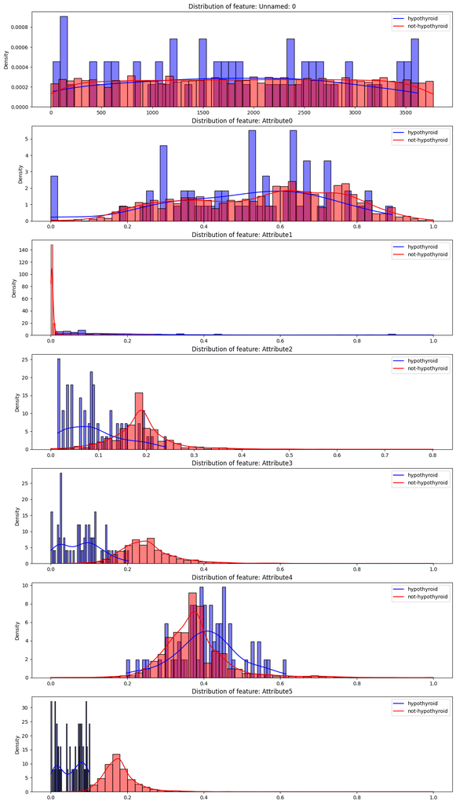

```python
import matplotlib.gridspec as gridspec
features=list(df.columns[:-1])
nplots=np.size(features)
plt.figure(figsize=(15,4*nplots))
gs = gridspec.GridSpec(nplots,1)
for i, feat in enumerate(features):
    print(feat)
    ax = plt.subplot(gs[i])
    sns.histplot(X_train[feat][y_train==1], stat="density", kde=True, color="blue", bins=50)
    sns.histplot(X_train[feat][y_train==0], stat="density", kde=True, color="red", bins=50)
    ax.legend(['hypothyroid', 'not-hypothyroid'],loc='best')
    ax.set_xlabel('')
    ax.set_title('Distribution of feature: ' + feat)
```

Explain how these graphs could provide meaningful information about anomaly detection using a gaussian model. The distribution graphs illustrate how each feature (columns 1 to 7) relates to the hypothyroid and non-hypothyroid classes by comparing their density distributions. A clear difference between the blue and red curves indicates that an attribute is effective at distinguishing between the two conditions, while an overlap provides less information for classification. The curve patterns can be used in detecting anomalies within a Gaussian model since the features following a normal distribution can help establish thresholds, allowing us to identify data points that fall outside the expected range as potential anomalies. These insights enhance the understanding of feature importance that can be used to improve the model performance.

## Part 2: Single feature model with one Gaussian distribution:

We'll start by making a prediction using **a single feature of our dataset at a time**.

**a. Fitting regardless of class:**

1. Fit a single Gaussian distribution on a single feature of **the full training dataset** (both classes) using `sklearn.mixture.GaussianMixture` when `n_components=1`.
2. Compute AUC (Area under the ROC Curve) based on `sklearn.mixture.GaussianMixture.score_samples` on both the full training set and validation set (including both classes).
3. Repeat the above steps for each of the features and present your findings in a table.

| Feature | Train AUC | Validation AUC | F1 Score | Threshold |
| --- | --- | --- | --- | --- |
| Unnamed: 0 | 0.492407 | 0.391168 | 0.051635 | 0.001 |
| Attribute0 | 0.456077 | 0.522868 | 0.052632 | 1.000 |
| Attribute1 | 0.950651 | 0.995523 | 0.695652 | 0.001 |
| Attribute2 | 0.805685 | 0.829704 | 0.313725 | 0.020 |
| Attribute3 | 0.940328 | 0.949123 | 0.431373 | 0.200 |
| Attribute4 | 0.577292 | 0.594918 | 0.000000 | 0.000 |
| Attribute5 | 0.967175 | 0.965638 | 0.473684 | 1.000 |

4. Find the best 3 features to distinguish hypothyroid patients from not-hypothyroid patients based on the AUC of the validation set.

```
The best 3 features are Attribute 1, Attribute 3, and Attribute 5, corresponding to the 3 highest validation AUC.
```

5. Make a prediction based on a model's scores: If the `score_samples` is lower than a threshold, we consider that patient as hypothyroid. Find an optimal threshold that maximizes the F1 Score of the validation set for each of those 3 features separately. (Do not check every possible value for threshold, come up with a faster way!) Compute F1 score using `sklearn.metrics.f1_score`.

```
For Attribute 1, the best threshold is 0.001 with the maximum F1 score of about 0.696.  For Attribute 3, the best threshold is 0.2 with the maximum F1 score of about 0.431. For Attribute 5, the best threshold is 1 with the maximum F1 score of about 0.474.
```

6. Report the complexity of your method (Big O notation) for determining the optimal threshold.

```
The complexity of determining the optimal threshold is O(mn), where m is the number of possible threshold and n is the number of samples that are used in predictions and the computation of F1 score.
```

**b. Fitting based on class:**

1. Pick 3 features that had the best AUC in Part 2a.
2. Compute AUC and F1 score when you fit a Gaussian **only on not-hypothyroid patients** (instead of all the patients).
3. Compare your results from parts 2a and 2b (AUC and F1 score) in a table.

| Feature | Train AUC | Train AUC Class0 | Validation AUC | Validation AUC Class0 | F1 Score | F1 Score Class0 |
| --- | --- | --- | --- | --- | --- | --- |
| Attribute1 | 0.950651 | 0.991473 | 0.995523 | 0.995523 | 0.695652 | 0.800000 |
| Attribute3 | 0.940328 | 0.945490 | 0.949123 | 0.953479 | 0.431373 | 0.465116 |
| Attribute5 | 0.967175 | 0.970353 | 0.965638 | 0.969873 | 0.473684 | 0.512821 |

4. Are these results different or similar? Why?

The AUC and F1 scores between the two Gaussian models are nearly the same, with the model fitted only on not-hypothyroid (Class 0) resulting in slightly higher scores. This similarity is primarily due to the class imbalance in the dataset, which contains a majority of not-hypothyroid samples. As a result, the scores obtained from fitting the Gaussian model on both classes are almost identical to those from fitting it on Class 0 alone, as the dataset is dominated by the not-hypothyroid class, capturing more points in that category.

```python
from sklearn.metrics import roc_curve, auc, f1_score
from sklearn.mixture import GaussianMixture

rows = []
tr_list = [0.001, 0.01, 0.02, 0.03, 0.1 , 0.2 , 1]
for feature in X_train.columns:
  # fit Gaussian distribution on single feature of training data
  gm = GaussianMixture(n_components = 1, covariance_type = 'full', random_state=0)
  gm.fit(X_train[[feature]])

  # get weighted log probabilities of each sample for both train and validation
  p = gm.score_samples(X_train[[feature]])
  p_val = gm.score_samples(X_val[[feature]])

  # compute AUC
  fpr, tpr, _ = roc_curve(y_train, -1 * p)
  fpr_val, tpr_val, thresholds = roc_curve(y_val, -1 * p_val)
  auc_train = auc(fpr, tpr)
  auc_val = auc(fpr_val, tpr_val)

  best_f1 = 0
  best_tr = 0
  for tr in tr_list:
    # predict based on threshold
    prediction = (-1 * p_val) >= tr
    curr_f1 = f1_score(y_val, prediction)

    # optimize f1 score
    if curr_f1 > best_f1:
      best_f1 = curr_f1
      best_tr = tr
  rows.append([feature, auc_train, auc_val, best_f1, best_tr])

  # print(f"Feature: {feature}, Train AUC: {auc_train:.3f}, Validation AUC: {auc_val:.3f}")
auc_df = pd.DataFrame(rows, columns=['Feature', 'Train AUC', 'Validation AUC', 'F1 Score', 'Threshold'])
print(auc_df)
```

```
      Feature  Train AUC  Validation AUC  F1 Score  Threshold
0  Unnamed: 0   0.492407        0.391168  0.051635      0.001
1  Attribute0   0.456077        0.522868  0.052632      1.000
2  Attribute1   0.950651        0.995523  0.695652      0.001
3  Attribute2   0.805685        0.829704  0.313725      0.020
4  Attribute3   0.940328        0.949123  0.431373      0.200
5  Attribute4   0.577292        0.594918  0.000000      0.000
6  Attribute5   0.967175        0.965638  0.473684      1.000
```

```python
# 3 best features
best_features = ['Attribute1', 'Attribute3', 'Attribute5']

rows = []
for feature in best_features:
  # filter non-hypothyroid patients
  X_train_class0 = X_train[y_train == 0.0][[feature]]

  # fit a Gaussian only on non-hypothyroid patients
  gm_class0 = GaussianMixture(n_components=1, covariance_type='full', random_state=0)
  gm_class0.fit(X_train_class0)

  # get weighted log probabilities
  p = gm_class0.score_samples(X_train[[feature]])
  p_val = gm_class0.score_samples(X_val[[feature]])

  # compute AUC
  fpr, tpr, _ = roc_curve(y_train, -1 * p)
  fpr_val, tpr_val, _ = roc_curve(y_val, -1 * p_val)
  auc_train = auc(fpr, tpr)
  auc_val = auc(fpr_val, tpr_val)

  best_f1 = 0
  best_tr = 0
  tr_list = [0.001, 0.01, 0.02, 0.03, 0.1, 0.2, 1]
  for tr in tr_list:
    # predict based on threshold
    prediction_val = (-1 * p_val) >= tr
    curr_f1 = f1_score(y_val, prediction_val)

    # optimize f1 score
    if curr_f1 > best_f1:
      best_f1 = curr_f1
      best_tr = tr

  rows.append([feature, auc_train, auc_val, best_f1, best_tr])

auc_df_class0 = pd.DataFrame(rows, columns=["Feature", "Train AUC Class0", "Validation AUC Class0", "F1 Score Class0", "Threshold"])
# print(auc_df_class0)

joint_df = pd.merge(auc_df, auc_df_class0, on='Feature')
joint_df = joint_df[['Feature', 'Train AUC', 'Train AUC Class0', 'Validation AUC', 'Validation AUC Class0', 'F1 Score', 'F1 Score Class0']]

print(joint_df)
```

```
      Feature  Train AUC  Train AUC Class0  Validation AUC  \
0  Attribute1   0.950651          0.991473        0.995523
1  Attribute3   0.940328          0.945490        0.949123
2  Attribute5   0.967175          0.970353        0.965638

   Validation AUC Class0  F1 Score  F1 Score Class0
0               0.995523  0.695652         0.800000
1               0.953479  0.431373         0.465116
2               0.969873  0.473684         0.512821
```

## Part 3: Multiple feature model with one Gaussian distribution:

This part is similar to Part 2, but we will pick multiple features and **visually** set the number of components of the GM model.

a. 2D plot:

1. Pick two features (say, Attribute1 and Attribute2).
2. Scatter plot (plt.scatter) those features on a figure (Attribute1 on the x-axis and Attribute2 on the y-axis).
3. Color the data points based on their class (not-hypothyroid blue and hypothyroid red).
4. Based on your plots, decide how many Gaussian components (`n_components`) you need to fit the data (focus on not-hypothyroid patients). Explain.

5. Fit your Gaussian model on all the data points.
6. Compute AUC on both training and validation sets

Attribute1 vs Attribut2: Train AUC: 0.986, Validation AUC: 0.986

Attribute1 vs Attribut3: Train AUC: 0.989, Validation AUC: 0.990

Attribute3 vs Attribut5: Train AUC: 0.956, Validation AUC: 0.952

7. Pick 3 new pairs of features and repeat steps 2 to 6.
8. For each pair, find a threshold to maximize your validation set F1 Score.

Attribute1 vs Attribut2: Best threshold: 0.001, Best F1 Score: 0.684

Attribute1 vs Attribut3: Best threshold: 0.001, Best F1 Score: 0.727

Attribute3 vs Attribut5: Best threshold: 1, Best F1 Score: 0.588

9. For each pair, plot a figure similar to step 3 and put a circle around outliers based on your threshold (use the code of the similar figure in the tutorial)

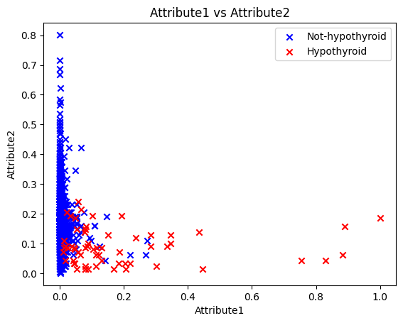

```
Train AUC: 0.986, Validation AUC: 0.986
Best threshold: 0.001, Best F1 Score: 0.684
```

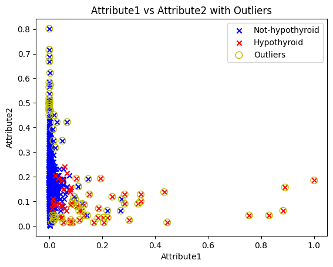

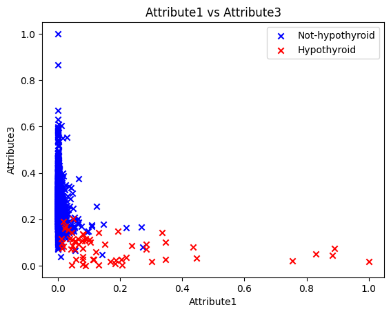

```
Train AUC: 0.989, Validation AUC: 0.990
Best threshold: 0.001, Best F1 Score: 0.727
```

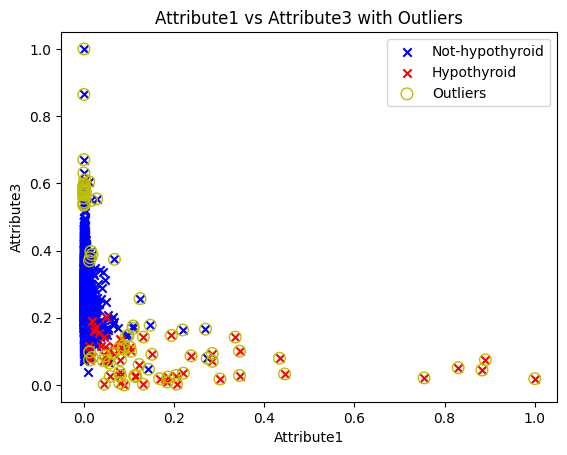

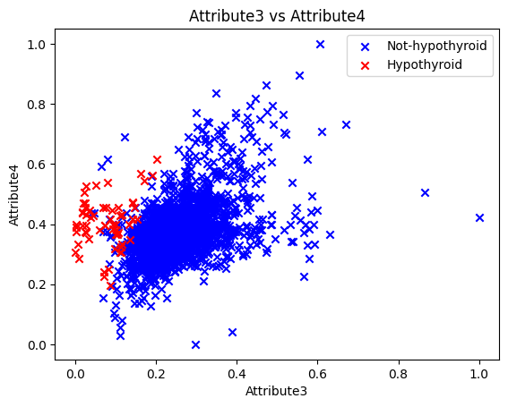

```
Train AUC: 0.964, Validation AUC: 0.969
Best threshold: 1, Best F1 Score: 0.488
```

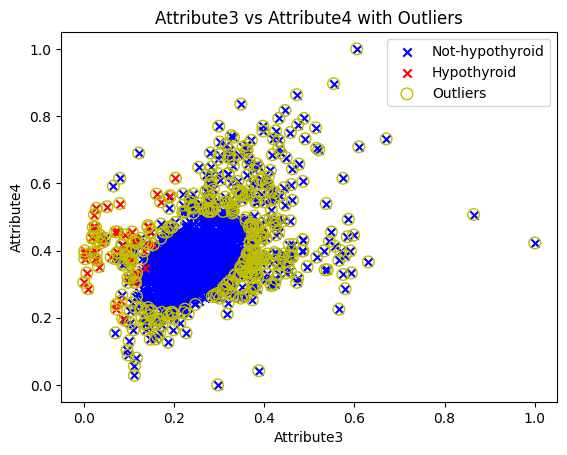

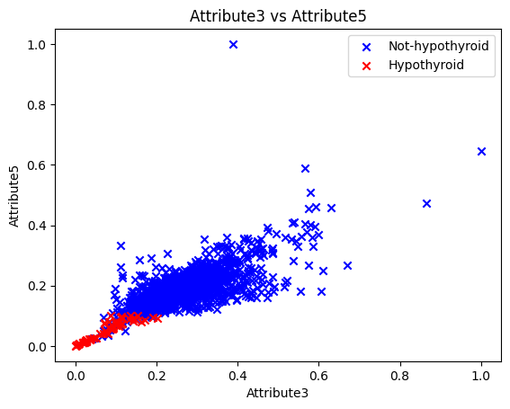

```
Train AUC: 0.956, Validation AUC: 0.952
Best threshold: 1, Best F1 Score: 0.588
```

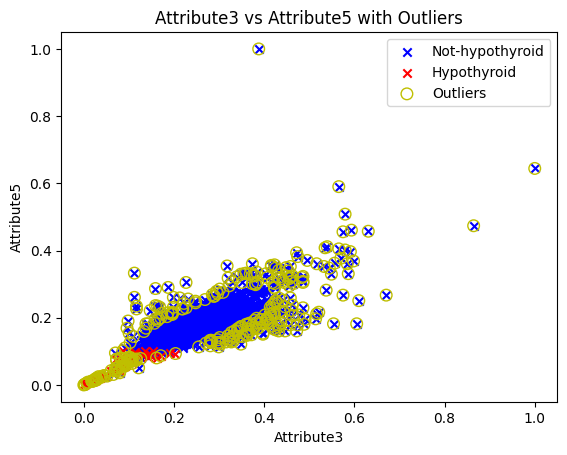

```python
class0 = X_train[y_train == 0]
class1 = X_train[y_train == 1]

def PlotScatter(feature1, feature2):
  plt.scatter(class0[feature1], class0[feature2], marker="x", color='blue', label='Not-hypothyroid')
  plt.scatter(class1[feature1], class1[feature2], marker="x", color='red', label='Hypothyroid')

  plt.xlabel(feature1)
  plt.ylabel(feature2)
  plt.title(feature1 + " vs " + feature2)
  plt.legend()

  plt.show()

def FitGaussianOnPair(feature1, feature2, n_components):
  # fit Gaussian
  gm = GaussianMixture(n_components=n_components, covariance_type='full', random_state=0)
  gm.fit(X_train[y_train==0][[feature1, feature2]])

  # get weighted log probabilities of each sample for both train and validation
  p = gm.score_samples(X_train[[feature1, feature2]])
  p_val = gm.score_samples(X_val[[feature1, feature2]])

  # compute AUC
  fpr, tpr, _ = roc_curve(y_train, -1 * p)
  fpr_val, tpr_val, thresholds = roc_curve(y_val, -1 * p_val)
  auc_train = auc(fpr, tpr)
  auc_val = auc(fpr_val, tpr_val)

  print(f"Train AUC: {auc_train:.3f}, Validation AUC: {auc_val:.3f}")

  # find optimized f1
  best_f1 = 0
  best_tr = 0
  tr_list = [0.001, 0.01, 0.02, 0.03, 0.1, 0.2, 1]
  for tr in tr_list:
    # predict based on threshold
    prediction_val = (-1 * p_val) >= tr
    curr_f1 = f1_score(y_val, prediction_val)

    # optimize f1 score
    if curr_f1 > best_f1:
        best_f1 = curr_f1
        best_tr = tr

  print(f"Best threshold: {best_tr}, Best F1 Score: {best_f1:.3f}")

  plt.scatter(class0[feature1], class0[feature2], marker="x", color='blue', label='Not-hypothyroid')
  plt.scatter(class1[feature1], class1[feature2], marker="x", color='red', label='Hypothyroid')

  # circle anomalies/outliers
  outliers = np.nonzero(p<best_tr)[0]
  plt.scatter(X_train.iloc[outliers][feature1], X_train.iloc[outliers][feature2], marker="o",
              facecolor="none", edgecolor="y", s=70, label="Outliers")

  plt.xlabel(feature1)
  plt.ylabel(feature2)
  plt.title(f"{feature1} vs {feature2} with Outliers")
  plt.legend()
  plt.show()

# Attribute1 vs Attribute2
PlotScatter('Attribute1', 'Attribute2')
FitGaussianOnPair('Attribute1', 'Attribute2', 2)

# Attribute1 vs Attribute3
PlotScatter('Attribute1', 'Attribute3')
FitGaussianOnPair('Attribute1', 'Attribute3', 2)

# Attribute3 vs Attribute4
PlotScatter('Attribute3', 'Attribute4')
FitGaussianOnPair('Attribute3', 'Attribute4', 2)

# Attribute3 vs Attribute5
PlotScatter('Attribute3', 'Attribute5')
FitGaussianOnPair('Attribute3', 'Attribute5', 2)
```

## Part 4: Single feature model with two Gaussian distributions.

Now we will use two different distributions for hypothyroid and not-hypothyroid patients.

1. Fit a Gaussian distribution ($G_1$) on a feature of **not-hypothyroid patients** using `sklearn.mixture.GaussianMixture` when `n_components=1`.
2. Fit another Gaussian distribution ($G_2$) on the same feature but for **hypothyroid patients** using `sklearn.mixture.GaussianMixture` when `n_components=1`.
3. Compute the score samples ($S$) for both $G_1$ and $G_2$ on the **validation set** to get $S_1$ and $S_2$, respectively.
4. Find an optimal $c$ (a real number) that maximizes validation set F1 Score for a model such that if $S_1 < c \times S_2$, the patient is classified as hypothyroid. For example, if $c=1$ we could say that if $S_2$ is greater than $S_1$, ($S_1$<$S_2$) then the patient is hypothyroid (the patient belongs to the $G_2$ distribution which represents hypothyroid patients). For start consider $c$ in $[0,10]$ with steps of 0.1, you can change this window in your experiments if needed.
5. Repeat the steps above for all the features. What is the best F1 Score that you get for training and validation? Which feature and what c?

Best feature for training: Attribute5

Best F1 score for training: 0.8028169014084507

Best c for training: 0.4

Best feature for validation: Attribute1

Best F1 score for validation: 0.8

Best c for validation: 0.0

```python
best_feature_train = None
best_feature_val = None
final_f1_train, final_f1_val, final_c_train, final_c_val = 0, 0, 0, 0
all_best_f1_train, all_best_f1_val, all_best_c_train, all_best_c_val = [], [], [], []

for feature in X_train.columns:
  # fit Gaussian on not-hypothyroid
  G1 = GaussianMixture(n_components = 1, covariance_type = 'full', random_state=0)
  G1.fit(class0[[feature]])

  # fit Gaussian on hypothyroid
  G2 = GaussianMixture(n_components = 1, covariance_type = 'full', random_state=0)
  G2.fit(class1[[feature]])

  # compute score samples on validation
  S1_train = G1.score_samples(X_train[[feature]])
  S2_train = G2.score_samples(X_train[[feature]])
  S1_val = G1.score_samples(X_val[[feature]])
  S2_val = G2.score_samples(X_val[[feature]])

  # find optimized f1
  best_f1_train, best_c_train, best_f1_val, best_c_val = 0, 0, 0, 0
  for c in np.arange(0, 10.1, 0.1):
    pred_train = S1_train < c * S2_train
    pred_val = S1_val < c * S2_val

    curr_f1_train = f1_score(y_train, pred_train)
    curr_f1_val = f1_score(y_val, pred_val)

    # optimize f1 score for train
    if curr_f1_train > best_f1_train:
      best_f1_train = curr_f1_train
      best_c_train = c

    # optimize f1 score for validation
    if curr_f1_val > best_f1_val:
      best_f1_val = curr_f1_val
      best_c_val = c

  all_best_f1_train.append(best_f1_train)
  all_best_f1_val.append(best_f1_val)
  all_best_c_train.append(best_c_train)
  all_best_c_val.append(best_c_val)

for i in range(len(X_train.columns)):
  if all_best_f1_train[i] > final_f1_train:
    final_f1_train = all_best_f1_train[i]
    final_c_train = all_best_c_train[i]
    best_feature_train = X_train.columns[i]

  if all_best_f1_val[i] > final_f1_val:
    final_f1_val = all_best_f1_val[i]
    final_c_val = all_best_c_val[i]
    best_feature_val = X_train.columns[i]

print(f"Best feature for training: {best_feature_train}")
print(f"Best F1 score for training: {final_f1_train}")
print(f"Best c for training: {final_c_train}")
print(f"Best feature for validation: {best_feature_val}")
print(f"Best F1 score for validation: {final_f1_val}")
print(f"Best c for validation: {final_c_val}")
```

```
Best feature for training: Attribute5
Best F1 score for training: 0.8028169014084507
Best c for training: 0.4
Best feature for validation: Attribute1
Best F1 score for validation: 0.8
Best c for validation: 0.0
```

## Part 5: Multivariate and Mixture of Gaussians Distribution

We now want to build an outlier detection model that performs well in terms of F1 score. To design your model:

- No restrictions on the number of features - use as few or as many as you want! (multivariate).
- To fit your model, you can take advantage of the Gaussian mixture model, where you can set the number of components [help](https://scikit-learn.org/stable/modules/generated/sklearn.mixture.GaussianMixture.html).
- You can choose to fit your Gaussians on not-hypothyroid patients or to both classes.

It is up to you how to design your model. Try at least 10 different models and report the AUC for both training and validation sets (if applicable) and the best F1 score for both training and validation sets for each model. What kind of model works better? How many features are best (and which ones)? How many Gaussians? How many components? Summarize your findings with tables or plots.

**HINT !**

You might want to try a two-gaussian model, multiple features, a single component for the not-hypothyroid patient, and multiple components for hypothyroid ones! Why does it make sense to have multiple components for hypothyroid patients?

The output table for 10 different models is shown below.

| Model ID | Features | n_components | Fit on | Train AUC | Validation AUC | Best F1 Train | Best F1 Validation | Best c Train | Best c Validation |
| --- | --- | --- | --- | --- | --- | --- | --- | --- | --- |
| 0 | All features | 1 | both | 0.004017 | 0.001936 | 0.739394 | 0.848485 | 1.3 | 0.6 |
| 1 | Attribute1, Attribute3, Attribute5 | 1 | hypothyroid | 0.036728 | 0.012220 | 0.132435 | 0.146341 | 0.1 | 0.1 |
| 2 | Attribute1, Attribute3 | 1 | not_hypothyroid | 0.036728 | 0.012220 | 0.132435 | 0.146341 | 0.1 | 0.1 |
| 3 | Attribute1, Attribute5 | 1 | both | 0.004647 | 0.002420 | 0.727273 | 0.838710 | 0.3 | 0.3 |
| 4 | Attribute3 | 1 | hypothyroid | 0.023522 | 0.019661 | 0.252137 | 0.272727 | 0.1 | 0.1 |
| 5 | All features | 2 | not_hypothyroid | 0.023522 | 0.019661 | 0.252137 | 0.272727 | 0.1 | 0.1 |
| 6 | Attribute1, Attribute3, Attribute5 | 2 | both | 0.003255 | 0.001089 | 0.852713 | 0.903226 | 0.6 | 0.6 |
| 7 | Attribute1, Attribute3 | 2 | hypothyroid | 0.059675 | 0.057713 | 0.128035 | 0.145833 | 0.1 | 0.1 |
| 8 | Attribute1, Attribute5 | 2 | not_hypothyroid | 0.059675 | 0.057713 | 0.128035 | 0.145833 | 0.1 | 0.1 |
| 9 | Attribute3 | 2 | both | 0.015030 | 0.011676 | 0.571429 | 0.600000 | 0.1 | 0.1 |

Model 6 has the best result. It uses 3 features: 'Attribute1', 'Attribute3', 'Attribute5', fits on both hypothyroid and not-hypothyroid classes with 2 components and 2 Gaussians. Consequently, it achieves the highest validation F1 score (0.903226) and has a small gap between training and validation performance, indicating the ability to fit the data and to generalize unseen samples.

```python
def fit_multi_gaussian_models(features_list, n_components_list, fit_on_list):
  rows = []
  model_id = 0
  for features in features_list:
    # fit Gaussian
    if fit_on_list[model_id] in ['both', 'not-hypothyroid']:
      G1 = GaussianMixture(n_components=n_components_list[model_id], covariance_type='full', random_state=0)
      G1.fit(class0[features])

    if fit_on_list[model_id] in ['both', 'hypothyroid']:
      G2 = GaussianMixture(n_components=n_components_list[model_id], covariance_type='full', random_state=0)
      G2.fit(class1[features])

    # compute scores on train and validation
    if fit_on_list[model_id] == 'both':
      S1_train = G1.score_samples(X_train[features])
      S2_train = G2.score_samples(X_train[features])
      S1_val = G1.score_samples(X_val[features])
      S2_val = G2.score_samples(X_val[features])
    elif fit_on_list[model_id] == 'not-hypothyroid':
      S1_train = G1.score_samples(X_train[features])
      S1_val = G1.score_samples(X_val[features])
      S2_train, S2_val = np.zeros(len(S1_train)), np.zeros(len(S1_val)) # discard G2 for hypothyroid
    elif fit_on_list[model_id] == 'hypothyroid':
      S2_train = G2.score_samples(X_train[features])
      S2_val = G2.score_samples(X_val[features])
      S1_train, S1_val = np.zeros(len(S2_train)), np.zeros(len(S2_val)) # discard G1 for not-hypothyroid

    # compute AUC on train and validation
    fpr_train, tpr_train, _ = roc_curve(y_train, S1_train - S2_train)
    auc_train = auc(fpr_train, tpr_train)

    fpr_val, tpr_val, _ = roc_curve(y_val, S1_val - S2_val)
    auc_val = auc(fpr_val, tpr_val)

    # find optimized f1
    best_f1_train, best_c_train, best_f1_val, best_c_val = 0, 0, 0, 0
    for c in np.arange(0, 10.1, 0.1):
      pred_train = S1_train < c * S2_train
      pred_val = S1_val < c * S2_val

      curr_f1_train = f1_score(y_train, pred_train)
      curr_f1_val = f1_score(y_val, pred_val)

      # optimize f1 score for train
      if curr_f1_train > best_f1_train:
        best_f1_train = curr_f1_train
        best_c_train = c

      # optimize f1 score for validation
      if curr_f1_val > best_f1_val:
        best_f1_val = curr_f1_val
        best_c_val = c

    # add row info
    rows.append({
      'Model ID': model_id,
      'Features': features,
      'n_components': n_components_list[model_id],
      'Fit on': fit_on_list[model_id],
      'Train AUC': auc_train,
      'Validation AUC': auc_val,
      'Best F1 Train': best_f1_train,
      'Best F1 Validation': best_f1_val,
      'Best c Train': best_c_train,
      'Best c Validation': best_c_val
    })

    model_id += 1
  return pd.DataFrame(rows)

# each list should have a length of 10 corresponding to 10 different models
features_list = [X_train.columns, ['Attribute1', 'Attribute3', 'Attribute5'],
          ['Attribute1', 'Attribute3'], ['Attribute1', 'Attribute5'],
          ['Attribute3'], X_train.columns, ['Attribute1', 'Attribute3', 'Attribute5'],
          ['Attribute1', 'Attribute3'], ['Attribute1', 'Attribute5'], ['Attribute3']]
n_components_list = [1, 1, 1, 1, 1, 2, 2, 2, 2, 2]
fit_on_list = ['both', 'hypothyroid', 'not_hypothyroid', 'both',
        'hypothyroid', 'not_hypothyroid', 'both',
        'hypothyroid', 'not_hypothyroid', 'both']

# output a table of 10 models
models_table = fit_multi_gaussian_models(features_list, n_components_list, fit_on_list)
print(models_table)
```

```
   Model ID                                           Features  n_components  \
0         0  Index(['Unnamed: 0', 'Attribute0', 'Attribute1...             1
1         1               [Attribute1, Attribute3, Attribute5]             1
2         2                           [Attribute1, Attribute3]             1
3         3                           [Attribute1, Attribute5]             1
4         4                                       [Attribute3]             1
5         5  Index(['Unnamed: 0', 'Attribute0', 'Attribute1...             2
6         6               [Attribute1, Attribute3, Attribute5]             2
7         7                           [Attribute1, Attribute3]             2
8         8                           [Attribute1, Attribute5]             2
9         9                                       [Attribute3]             2

            Fit on  Train AUC  Validation AUC  Best F1 Train  \
0             both   0.004017        0.001936       0.739394
1      hypothyroid   0.036728        0.012220       0.132435
```

[output cut: 20 more lines]

## **Part 6: Evaluating performance on test set: [1 Mark]**

**Which model worked better?** Pick your best model among all models and apply it to your test set. Report the F1 Score, Precision and Recall on the test set. **[1]**

Model 6 worked better. The F1 score on test set is 0.9143, precision is 0.8889, recall is 0.9412.

```python
from sklearn.metrics import precision_score, recall_score

features = ['Attribute1', 'Attribute3', 'Attribute5']

G1_test = GaussianMixture(n_components=2, covariance_type='full', random_state=0)
G1_test.fit(class0[features])

G2_test = GaussianMixture(n_components=2, covariance_type='full', random_state=0)
G2_test.fit(class1[features])

S1_test = G1_test.score_samples(X_test[features])
S2_test = G2_test.score_samples(X_test[features])

pred_test = S1_test < 0.6 * S2_test
f1_test = f1_score(y_test, pred_test)
pr_test = precision_score(y_test, pred_test)
rc_test = recall_score(y_test, pred_test)

print(f"F1 score on test: {f1_test:.4f}")
print(f"Precision on test: {pr_test:.4f}")
print(f"Recall on test: {rc_test:.4f}")
```

[output not shown]

## Part 7: Is Gaussian the only useful distribution?

Search for other distributions that could be used to model the data. How popular are they? Is there a specific situation where a distribution works better? How can we find a suitable distribution to model our data? Do not forget to include your references.

In Part 1, the plots have shown the distribution of each features in the dataset. The second, third, and fourth attributes illustrate a skewed shape of samples. In this case, we can use a Gamma distribution to fit the model. Adjusting the parameters can help to make better predictions by fitting the skewness, similar to identifying multiple components in Gaussian Model. We can find a suitable Gamma distribution by fine-tune the shape parameter 𝛼 and rate parameter 𝛽. Increasing 𝛼 moves the peak of the probability density function (PDF) to the right, fitting larger values within the data, while decreasing it shifts the peak to the left, highlighting lower values. Moreover, a higher 𝛽 flattens the PDF, which is ideal for capturing data with a long tail, whereas a lower 𝛽 is used to fit clustered data points. It is popular on positive variables with skewed distributions.

Furthermore, a Poisson Mixture Model can be well-suited for this thyroid dataset due to the key characteristics such as skewness, class imbalance, and the discrete data. Firstly, the Poisson distribution has the ability to model skewed data by modifiying the parameter λ, which controls both the mean and variance. Secondly, the data contains imbalanced classes, with the majority of samples belonging to class 0 (not-hypothyroid). This distribution can capture this skewness and adjust effectively for the sparse instances in class 1 (hypothyroid) without being overly influenced by the dominant class. Additionally, the Gaussian Mixture Model only assumes continuous, symmetric distributions, making it less ideal for modeling features with inherent skewness or sparsity. As a result, the Poisson distribution is popular for handling imbalanced and skewed data because they are flexible with data that comes in counts. This makes it a good choice for dataset like thyroid disease classification.

References:

Jia, Z., & Parekh, P. (2022, April 6). Using gamma distribution to improve long-tail event predictions. DoorDash. https://careersatdoordash.com/blog/using-gamma-distribution-to-improve-long-tail-event-predictions/#:~:text=Gamma%20distributions%20have%20been%20used,claims%2C%20wait%20time%2C%20etc.

Wang, K., Yau, K. K. W., Lee, A. H., & McLachlan, G. J. (2007). Two-component Poisson mixture regression modelling of count data with bivariate random effects. *Mathematical and Computer Modelling, 46*(11), 1468–1476. https://doi.org/10.1016/j.mcm.2007.02.003